# Pregunta 1: [20 puntos] Dada la siguiente Tabla de Testing de un Scoring de Crédito:

## 3. Repita los items 1) y 2) pero usando solamente los 3s, 5s y los 8s. ¿Mejora la predicción?

```python
#item 1
X_test = pd.read_csv('../datos/ZipDataTestCod.csv',delimiter=';',decimal=".")
X_train = pd.read_csv('../datos/ZipDataTrainCod.csv',delimiter=';',decimal=".")

#Filtro las filas 3s, 5s y 8s
X_train = X_train[(X_train.Numero == "cinco") | (X_train.Numero == "tres") | (X_train.Numero == "ocho")]

X_test = X_test[(X_test.Numero == "cinco") | (X_test.Numero == "tres") | (X_test.Numero == "ocho")]
```

```python
y_train = X_train["Numero"]
y_test = X_test["Numero"]

X_train = X_train.drop("Numero",1)
X_test = X_test.drop("Numero",1)
```

```python
instancia_knn = KNeighborsClassifier(n_neighbors=8)
instancia_knn.fit(X_train.values,y_train) #X_train sin variable a predecir
prediccion = instancia_knn.predict(X_test.values)  #X_test sin variable a predecir

# item 2
labels = ["tres","cinco","ocho"]
MC = confusion_matrix(y_test, prediccion,labels=labels)

indices = indices_general(MC,labels)
for k in indices:
    print("\n%s:\n%s"%(k,str(indices[k])))
```

```
Matriz de Confusión:
[[152  13   1]
 [  3 155   2]
 [  3   5 158]]

Precisión Global:
0.9451219512195121

Error Global:
0.054878048780487854

Precisión por categoría:
       tres    cinco      ocho
0  0.915663  0.96875  0.951807
```

Mejora en decimales, aunque la categoría del "ocho" aumenta mucho más que en el modelo anterior.

## 4. Repita los items 1) y 2) utilizando `n_neighbors=5` y `algorithm=‘‘auto’’` (parámetros por defecto) pero reemplazando cada bloque 4 × 4 de píxeles por su promedio. ¿Mejora la predicción? Recuerde que cada bloque 16 × 16 está representado por una fila en las matrices de aprendizaje y testing. Despliegue la matriz de confusión resultante. La matriz de confusión obtenida debería ser:

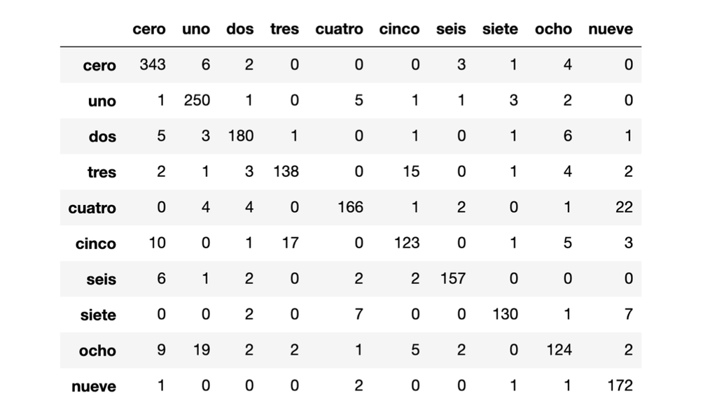

```python
X_test = pd.read_csv('../datos/ZipDataTestCod.csv',delimiter=';',decimal=".")
X_train = pd.read_csv('../datos/ZipDataTrainCod.csv',delimiter=';',decimal=".")


X_train1 = X_train.drop("Numero",1)
X_test1 = X_test.drop("Numero",1)
```

```python
def zipFila(fila, p = 4):
    tam = 16
    row = []
    for n in range(0,len(fila),tam * p):
        bloques = []
        for m in range(0, tam, p):
            subBloque = []
            for i in range(p):
                inicio = m + (tam*i) + n
                fin = inicio + p
                subBloque += list(fila[inicio:fin])
            bloques += [np.mean(subBloque)]

        row += bloques

    return row

def zipData(datos,p = 4):
    datosComprimidos = []
    for n in range(datos.shape[0]):
        datosComprimidos += [zipFila(datos.iloc[n,:],p)]

    return pd.DataFrame(datosComprimidos)


X_train1 = zipData(X_train1)
X_test1 = zipData(X_test1)
```

```python
y_train = X_train["Numero"]
y_test = X_test["Numero"]
```

```python
instancia_knn = KNeighborsClassifier(n_neighbors=5,algorithm="auto" )
instancia_knn.fit(X_train1.values,y_train) #X_train sin variable a predecir
prediccion = instancia_knn.predict(X_test1.values)  #X_test sin variable a predecir

# item 2
labels = ["cero","uno","dos","tres","cuatro","cinco","seis","siete","ocho","nueve"]
MC = confusion_matrix(y_test, prediccion,labels=labels)

indices = indices_general(MC,labels)
for k in indices:
    print("\n%s:\n%s"%(k,str(indices[k])))
```

```
Matriz de Confusión:
[[343   6   2   0   0   0   3   1   4   0]
 [  1 250   1   0   5   1   1   3   2   0]
 [  5   3 180   1   0   1   0   1   6   1]
 [  2   1   3 138   0  15   0   1   4   2]
 [  0   4   4   0 166   1   2   0   1  22]
 [ 10   0   1  17   0 123   0   1   5   3]
 [  6   1   2   0   2   2 157   0   0   0]
 [  0   0   2   0   7   0   0 130   1   7]
 [  9  19   2   2   1   5   2   0 124   2]
 [  1   0   0   0   2   0   0   1   1 172]]

Precisión Global:
0.8883906327852517

Error Global:
0.11160936721474835

Precisión por categoría:
       cero      uno       dos      tres  cuatro    cinco      seis     siete  \
0  0.955432  0.94697  0.909091  0.831325    0.83  0.76875  0.923529  0.884354

       ocho     nueve
0  0.746988  0.971751
```

No mejora la predicción

## 5. Repita los items 1) y 2) pero reemplazando cada bloque p×p de píxeles por su promedio. ¿Mejora la predicción? (pruebe con algunos valores de p). Despliegue las matrices de confusión resultantes.

- ### $ p = 2$

```python
X_test = pd.read_csv('../datos/ZipDataTestCod.csv',delimiter=';',decimal=".")
X_train = pd.read_csv('../datos/ZipDataTrainCod.csv',delimiter=';',decimal=".")


X_train1 = X_train.drop("Numero",1)
X_test1 = X_test.drop("Numero",1)

X_train1 = zipData(X_train1, p = 2)
X_test1 = zipData(X_test1, p = 2)

y_train = X_train["Numero"]
y_test = X_test["Numero"]

instancia_knn = KNeighborsClassifier(n_neighbors=5,algorithm="auto" )
instancia_knn.fit(X_train1.values,y_train) #X_train sin variable a predecir
prediccion = instancia_knn.predict(X_test1.values)  #X_test sin variable a predecir

# item 2
labels = ["cero","uno","dos","tres","cuatro","cinco","seis","siete","ocho","nueve"]
MC = confusion_matrix(y_test, prediccion,labels=labels)

indices = indices_general(MC,labels)
for k in indices:
    print("\n%s:\n%s"%(k,str(indices[k])))
```

```
Matriz de Confusión:
[[355   0   3   0   0   0   0   0   0   1]
 [  0 259   0   0   3   0   2   0   0   0]
 [  6   0 179   2   1   0   2   2   6   0]
 [  3   0   2 152   0   7   0   1   0   1]
 [  0   2   3   0 190   0   0   2   0   3]
 [  3   1   2   2   0 147   0   0   1   4]
 [  1   0   2   0   2   0 164   0   1   0]
 [  0   0   0   2   3   1   0 135   2   4]
 [  4   2   0   2   0   4   0   0 150   4]
 [  1   1   1   0   2   0   0   1   1 170]]

Precisión Global:
0.9471848530144494

Error Global:
0.052815146985550565

Precisión por categoría:
       cero       uno      dos      tres  cuatro    cinco      seis     siete  \
0  0.988858  0.981061  0.90404  0.915663    0.95  0.91875  0.964706  0.918367

       ocho     nueve
0  0.903614  0.960452
```

- ### $p = 6$

```python
X_test = pd.read_csv('../datos/ZipDataTestCod.csv',delimiter=';',decimal=".")
X_train = pd.read_csv('../datos/ZipDataTrainCod.csv',delimiter=';',decimal=".")


X_train1 = X_train.drop("Numero",1)
X_test1 = X_test.drop("Numero",1)

X_train1 = zipData(X_train1, p = 6)
X_test1 = zipData(X_test1, p = 6)

y_train = X_train["Numero"]
y_test = X_test["Numero"]

instancia_knn = KNeighborsClassifier(n_neighbors=5,algorithm="auto" )
instancia_knn.fit(X_train1.values,y_train) #X_train sin variable a predecir
prediccion = instancia_knn.predict(X_test1.values)  #X_test sin variable a predecir

# item 2
labels = ["cero","uno","dos","tres","cuatro","cinco","seis","siete","ocho","nueve"]
MC = confusion_matrix(y_test, prediccion,labels=labels)

indices = indices_general(MC,labels)
for k in indices:
    print("\n%s:\n%s"%(k,str(indices[k])))
```

```
Matriz de Confusión:
[[343   0   1   3   0   1   6   0   4   1]
 [  2 252   1   0   2   3   2   0   0   2]
 [  2   0 153  14   4  17   2   1   5   0]
 [  6   0   5 121   0  21   0   2   9   2]
 [  1   3   6   0 161   1   2   3   1  22]
 [  9   0   6  27   1 101   2   2   9   3]
 [  1   1   5   0   2   1 160   0   0   0]
 [  0   1   1   0   2   2   0 118   4  19]
 [  7   1   4   4   1   6   4   4 128   7]
 [  0   0   0   0   7   0   0  14   4 152]]

Precisión Global:
0.8415545590433483

Error Global:
0.1584454409566517

Precisión por categoría:
       cero       uno       dos      tres  cuatro    cinco      seis  \
0  0.955432  0.954545  0.772727  0.728916   0.805  0.63125  0.941176

      siete      ocho     nueve
0  0.802721  0.771084  0.858757
```

- ### $p = 8$

```python
X_test = pd.read_csv('../datos/ZipDataTestCod.csv',delimiter=';',decimal=".")
X_train = pd.read_csv('../datos/ZipDataTrainCod.csv',delimiter=';',decimal=".")


X_train1 = X_train.drop("Numero",1)
X_test1 = X_test.drop("Numero",1)

X_train1 = zipData(X_train1, p = 8)
X_test1 = zipData(X_test1, p = 8)

y_train = X_train["Numero"]
y_test = X_test["Numero"]

instancia_knn = KNeighborsClassifier(n_neighbors=5,algorithm="auto" )
instancia_knn.fit(X_train1.values,y_train) #X_train sin variable a predecir
prediccion = instancia_knn.predict(X_test1.values)  #X_test sin variable a predecir

# item 2
labels = ["cero","uno","dos","tres","cuatro","cinco","seis","siete","ocho","nueve"]
MC = confusion_matrix(y_test, prediccion,labels=labels)

indices = indices_general(MC,labels)
for k in indices:
    print("\n%s:\n%s"%(k,str(indices[k])))
```

```
Matriz de Confusión:
[[316   9   9   3   3   2   0   0  17   0]
 [ 11 226   7   5   1   0   1   5   7   1]
 [ 25   6 128   5  13   3  12   0   6   0]
 [ 15   3   5  88  15  20   0   3  11   6]
 [ 10  12  18  19  61  30   2   8  14  26]
 [ 24   3   3  20  15  88   0   1   2   4]
 [  6   0  14   0   1   2 147   0   0   0]
 [  0   0   0   6   3   1   0 108   2  27]
 [ 48  18   8  11   4   4   1   0  67   5]
 [  1   1   0   8  10   3   0  23   4 127]]

Precisión Global:
0.6756352765321375

Error Global:
0.3243647234678625

Precisión por categoría:
       cero       uno       dos     tres  cuatro  cinco      seis     siete  \
0  0.880223  0.856061  0.646465  0.53012   0.305   0.55  0.864706  0.734694

       ocho     nueve
0  0.403614  0.717514
```

Para $p = 2$ mejora la predicción con respecto a la original, incluso para el "ocho". Sin embargo, conforme vamos aumentando $p$ la calidad del modelo disminuye considerablemente.